# Final Project_Part 2

Shreya Agrawal, Elizabeth Imhoff, Emily Jolly

10/20/2021

```r
file="/Users/emilyjolly/Documents/Classes/STAT 1261/titanic.csv"
titanic=read.csv(file)
```

# Introduction

When the Titanic sank in 1912, there were not enough lifeboats for all passengers on board. In addition, those who did get to board a lifeboat were not chosen randomly as women and children in first class were asked to board first, having been given priority seating. This data set contains information regarding 891 different passengers including whether they survived, their sex, their class, and the people with which they were travelling. The purpose of this study is to analyze whether these factors (being a young, upper-class woman) really did an effective job of increasing one’s chances of survival on the Titanic or whether, in spite of these prioritizations, a wide variety of different passengers were able to survive.

A link to the data set can be found here: https://www.kaggle.com/c/titanic/data?select=gender_submission.csv

```r
head(titanic)
```

```
##   PassengerId Survived Pclass
## 1           1        0      3
## 2           2        1      1
## 3           3        1      3
## 4           4        1      1
## 5           5        0      3
## 6           6        0      3
##                                                  Name    Sex Age SibSp Parch
## 1                             Braund, Mr. Owen Harris   male  22     1     0
## 2 Cumings, Mrs. John Bradley (Florence Briggs Thayer) female  38     1     0
## 3                              Heikkinen, Miss. Laina female  26     0     0
## 4        Futrelle, Mrs. Jacques Heath (Lily May Peel) female  35     1     0
## 5                            Allen, Mr. William Henry   male  35     0     0
## 6                                    Moran, Mr. James   male  NA     0     0
##             Ticket    Fare Cabin Embarked
## 1        A/5 21171  7.2500              S
## 2         PC 17599 71.2833   C85        C
## 3 STON/O2. 3101282  7.9250              S
## 4           113803 53.1000  C123        S
## 5           373450  8.0500              S
## 6           330877  8.4583              Q
```

# Survivorship by Age

If children were given priority seating on the lifeboats, perhaps we should begin our analysis by assessing whether people in lower age groups had a higher chance of survival.

### Finding the Age Range

```r
titanic %>% summarise(max.age=max(Age, na.rm=TRUE), min.age=min(Age, na.rm=TRUE))
```

```
##   max.age min.age
## 1      80    0.42
```

This tells us the highest age of passengers aboard the Titanic was 80, and the lowest was approximately 0.

### Visualizing Survivorship by Age

As can be seen by the visualization below, the highest proportion of survivors came from passengers who were 0 to 10 years old. The lowest proportion of survivers came from passengers who were 70 to 80 years old.

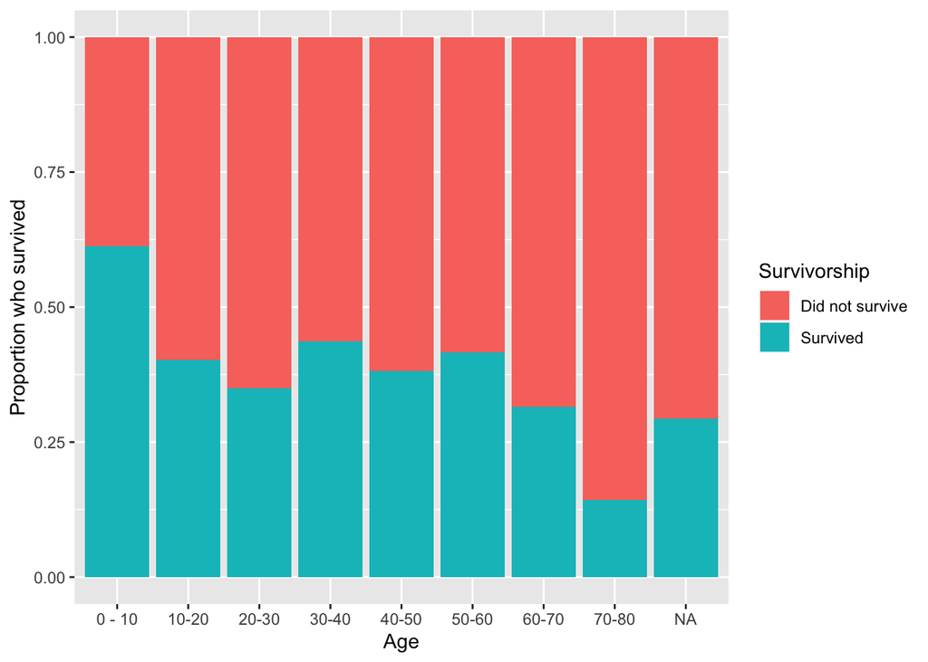

```r
titanicNew <- titanic %>% mutate(AgeIncrements = ifelse(Age < 10, "0 - 10",ifelse(Age < 20, "10-20",ifelse(Age < 30,"20-30",ifelse(Age < 40,"30-40",ifelse(Age < 50,"40-50",ifelse(Age < 60,"50-60",ifelse(Age < 70,"60-70","70-80"))))))))

g <- ggplot(data = titanicNew,aes(x = AgeIncrements)) +
geom_bar(aes(fill = factor(Survived)),position = "fill") + ylab("Proportion who survived") + xlab("Age") + scale_fill_discrete(name="Survivorship",
                       labels=c("Did not survive", "Survived"))

g
```

As can be observed by the box plots, the age distribution for those who survived versus for those who did not survive, are both very similar. This could indicate that the age of a passenger did not have a very strong effect on their likelihood for survival.

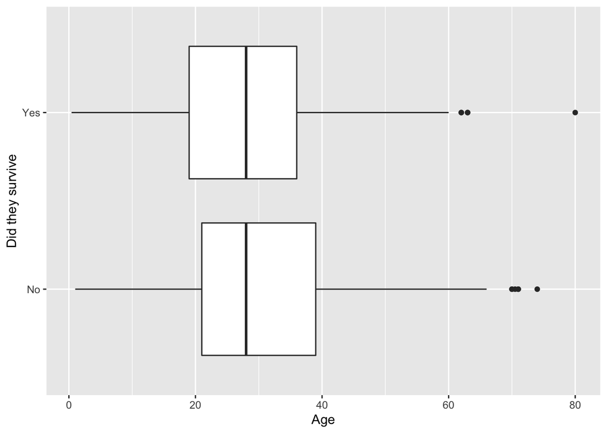

```r
titanic %>%
  ggplot(aes(x = factor(Survived), y= Age)) +
  geom_boxplot()+
  scale_x_discrete(breaks=c(0,1), labels=c("0"="No", "1"="Yes"))+
  xlab("Did they survive")+
  coord_flip()
```

```r
titanic %>%
  group_by(factor(Survived)) %>%
  summarise(favstats(Age))
```

```
## # A tibble: 2 × 10
##   `factor(Survived)`   min    Q1 median    Q3   max  mean    sd     n missing
##   <fct>              <dbl> <dbl>  <dbl> <dbl> <dbl> <dbl> <dbl> <int>   <int>
## 1 0                   1       21     28    39    74  30.6  14.2   424     125
## 2 1                   0.42    19     28    36    80  28.3  15.0   290      52
```

### Regression Model and Confidence Interval

```r
mod <- lm(Survived ~ Age, data = titanic)
summary(mod)
```

```
##
## Call:
## lm(formula = Survived ~ Age, data = titanic)
##
## Residuals:
##     Min      1Q  Median      3Q     Max
## -0.4811 -0.4158 -0.3662  0.5789  0.7252
##
## Coefficients:
##              Estimate Std. Error t value Pr(>|t|)
## (Intercept)  0.483753   0.041788  11.576   <2e-16 ***
## Age         -0.002613   0.001264  -2.067   0.0391 *
## ---
## Signif. codes:  0 '***' 0.001 '**' 0.01 '*' 0.05 '.' 0.1 ' ' 1
##
## Residual standard error: 0.4903 on 712 degrees of freedom
##   (177 observations deleted due to missingness)
## Multiple R-squared:  0.005963,   Adjusted R-squared:  0.004567
## F-statistic: 4.271 on 1 and 712 DF,  p-value: 0.03912
```

```r
confint(mod,'Age',data=titanic)
```

```
##           2.5 %        97.5 %
## Age -0.00509439 -0.0001306918
```

```r
tidyTitanic <- titanic %>% drop_na(Age)

meanAge <- mean(tidyTitanic$Age)

stdevAge <- sd(tidyTitanic$Age)
```

The Null Hypothesis is that correlation between Age and Survived is 0. The Alternative Hypothesis is that correlation is not 0. As can be seen by the test results, for females, there is not a correlation between age and whether or not they survived because the p-value is not less than 0.05. For males, there is a correlation between age and whether or not they survived because the p-value is less than 0.05. The correlation coefficient estimate for females is approximately 0.1161, weak positive correlation. The correlation coefficient estimate for males is approximately -0.1196, weak negative correlation.

```r
tidyTitanic %>%
  group_by(Sex) %>%
  do(tidy(cor.test(~ Age + Survived, alternative = "two.sided", data = . )))
```

```
## # A tibble: 2 × 9
## # Groups:   Sex [2]
##   Sex    estimate statistic p.value parameter conf.low conf.high method
##   <chr>     <dbl>     <dbl>   <dbl>     <int>    <dbl>     <dbl> <chr>
## 1 female    0.116      1.88  0.0611       259 -0.00539    0.234  Pearson's prod…
## 2 male     -0.120     -2.56  0.0108       451 -0.209     -0.0278 Pearson's prod…
## # … with 1 more variable: alternative <chr>
```

# Survivorship by Sex

Because women and children were supposedly given priority seating on the few lifeboats available, it is important to assess whether significantly more women survived the incident than men. This means that our null hypothesis is that there is no significant difference between the survival of women and men on the Titanic.

### Visualizing Survivorship by Sex

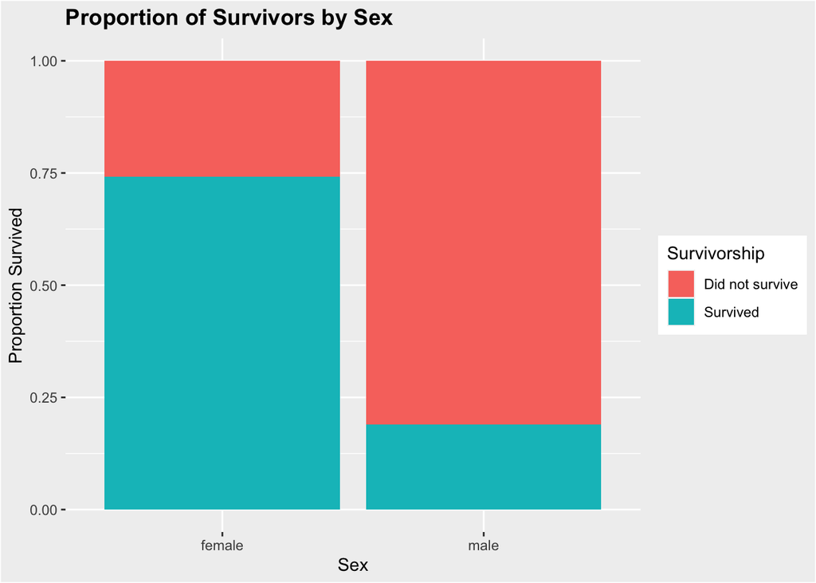

```r
titanic.f=titanic %>% mutate(Survived.f=as.factor(Survived))

sex_plot=ggplot(titanic.f, mapping=aes(x=Sex, fill=Survived.f)) +
  geom_bar(position="fill") +
  labs(title="Proportion of Survivors by Sex") +
  xlab("Sex") + ylab("Proportion Survived") +
  scale_fill_discrete(name="Survivorship",
                       labels=c("Did not survive", "Survived")) +
  theme(plot.background=element_rect("#f0f0f0"),
        panel.background = element_rect(fill = "#f0f0f0"),
        plot.title = element_text(size = rel(1.25), face="bold"))
sex_plot
```

### Testing for Differences in Survivorship Between Sexes

```r
dim.male=titanic %>% filter(Sex=="male") %>% dim()
dim.female=titanic %>% filter(Sex=="female") %>% dim()

mal.surv=titanic %>% filter(Sex=="male") %>% summarise(sum(Survived)) %>% as.integer()
mal.dead=titanic %>% filter(Sex=="male") %>% summarise(dim.male[1]-sum(Survived)) %>% as.integer
fem.surv=titanic %>% filter(Sex=="female") %>% summarise(sum(Survived)) %>% as.integer
fem.dead=titanic %>% filter(Sex=="female") %>% summarise(dim.female[1]-sum(Survived)) %>% as.integer

sex.survivor=matrix(c(mal.dead,fem.dead,mal.surv,fem.surv),2,2,byrow=T)
colnames(sex.survivor)<-c("Male","Female")
rownames(sex.survivor)<-c("Died","Survived")
pander(sex.survivor)
```

|  | Male | Female |
| --- | --- | --- |
| **Died** | 468 | 81 |
| **Survived** | 109 | 233 |

```r
chisq.test(sex.survivor[1:2,1:2],correct=F)
```

```
##
##  Pearson's Chi-squared test
##
## data:  sex.survivor[1:2, 1:2]
## X-squared = 263.05, df = 1, p-value < 2.2e-16
```

Our null hypothesis is that there is no significant difference between male and female survivorship. By performing a chi-square test, we can assess whether the proportions of males and females who survived is actually significantly different. Again, we can see by the table that many more women survived while many more men died, and when looking at the p-value (2.2 x 10^-16) which is much lower than the necessary .05 cutoff, we can conclude that there is indeed a significant difference between the amount of men and women who survived. Thus, sex clearly played a role in increasing one’s chances of survival on the Titanic as significantly more women survived.

### Visualizing Differences in Survivorship due to Children

Women were not the only one’s given priority seating, however, as seats were reserved for children as well. Thus, we can continue to explore the data to see whether travelling with a child altered each sex’s chances of survival.

```r
child=titanic.f %>% filter(Parch>0) %>% mutate(Child=1)
no.child=titanic.f %>% filter(Parch==0) %>% mutate(Child=0)
titanic.f=full_join(child,no.child)
```

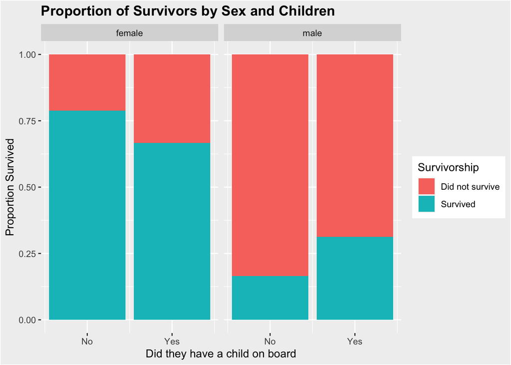

```r
child_plot=ggplot(titanic.f, mapping=aes(x=Child, fill=Survived.f)) +
  geom_bar(position="fill") +
  facet_wrap(~Sex) +
  labs(title="Proportion of Survivors by Sex and Children") +
  xlab("Did they have a child on board") + ylab("Proportion Survived") +
  scale_fill_discrete(name="Survivorship",
                       labels=c("Did not survive", "Survived")) +
  scale_x_continuous(breaks=c(0,1), labels=c("0"="No", "1"="Yes")) +
  theme(plot.background=element_rect("#f0f0f0"),
        panel.background = element_rect(fill = "#f0f0f0"),
        plot.title = element_text(size = rel(1.25), face="bold"))
child_plot
```

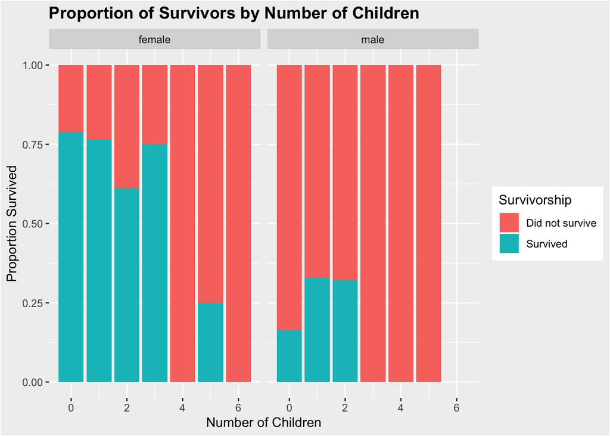

```r
num.child_plot=ggplot(titanic.f, mapping=aes(x=Parch, fill=Survived.f)) +
  geom_bar(position="fill") +
  facet_wrap(~Sex) +
  labs(title="Proportion of Survivors by Number of Children") +
  xlab("Number of Children") + ylab("Proportion Survived") +
  scale_fill_discrete(name="Survivorship",
                       labels=c("Did not survive", "Survived")) +
  theme(plot.background=element_rect("#f0f0f0"),
        panel.background = element_rect(fill = "#f0f0f0"),
        plot.title = element_text(size = rel(1.25), face="bold"))
num.child_plot
```

This first bar graph reveals that travelling with children decreased a woman’s chances of survival while it increased a man’s chances of survival. More than 75% of the women travelling without children, survived the incident while less than 75% of the women travelling with children survived. On the other hand, less than 25% of men travelling without children survived and more than 25% of men travelling with children survived. This should be a bit surprising as both women AND children were given priority seating on lifeboats, so to assess why women’s chances were not increased when travelling with children, we can further divide the data by the amount of children with which they were travelling.

The second bar graph reveals that, in general, the more children a woman had on board with her, the lower her chances of survival. Simultaneously, men had an increased chance of survival when travelling with only one or two children. This may be because crew members did not want to separate children from their parents and thus prioritized children and one of their guardians– even prioritizing men if the child’s mother was not on board. However, perhaps the more children the parent had, the less room there was for he or she to board the lifeboat as well. Thus, travelling with children could have increased each sex’s chances to an extent, but not when the number of children was large.

### Testing for Differences in Survivorship due to Children

```r
child.surv.f=titanic %>% filter(Sex=="female" & Parch>0 & Survived==1) %>% dim() %>% as.integer()
child.dead.f=titanic %>% filter(Sex=="female" & Parch>0 & Survived==0) %>% dim() %>% as.integer()
nochild.surv.f=titanic %>% filter(Sex=="female" & Parch==0 & Survived==1) %>% dim() %>% as.integer()
nochild.dead.f=titanic %>% filter(Sex=="female" & Parch==0 & Survived==0) %>% dim() %>% as.integer()

fem.child=matrix(c(child.dead.f[1],nochild.dead.f[1],child.surv.f[1],nochild.surv.f[1]),2,2,byrow=T)
colnames(fem.child)<-c("Had Child","Had no Child")
rownames(fem.child)<-c("Died","Survived")
pander(fem.child)
```

|  | Had Child | Had no Child |
| --- | --- | --- |
| **Died** | 40 | 41 |
| **Survived** | 80 | 153 |

```r
chisq.test(fem.child[1:2,1:2],correct=F)
```

```
##
##  Pearson's Chi-squared test
##
## data:  fem.child[1:2, 1:2]
## X-squared = 5.7642, df = 1, p-value = 0.01636
```

```r
child.surv.m=titanic %>% filter(Sex=="male" & Parch>0 & Survived==1) %>% dim() %>% as.integer()
child.dead.m=titanic %>% filter(Sex=="male" & Parch>0 & Survived==0) %>% dim() %>% as.integer()
nochild.surv.m=titanic %>% filter(Sex=="male" & Parch==0 & Survived==1) %>% dim() %>% as.integer()
nochild.dead.m=titanic %>% filter(Sex=="male" & Parch==0 & Survived==0) %>% dim() %>% as.integer()

mal.child=matrix(c(child.dead.m[1],nochild.dead.m[1],child.surv.m[1],nochild.surv.m[1]),2,2,byrow=T)
colnames(mal.child)<-c("Had Child","Had no Child")
rownames(mal.child)<-c("Died","Survived")
pander(mal.child)
```

|  | Had Child | Had no Child |
| --- | --- | --- |
| **Died** | 64 | 404 |
| **Survived** | 29 | 80 |

```r
chisq.test(mal.child[1:2,1:2],correct=F)
```

```
##
##  Pearson's Chi-squared test
##
## data:  mal.child[1:2, 1:2]
## X-squared = 10.933, df = 1, p-value = 0.0009447
```

The visible difference in each sex’s chances of survival due to children is small, so we cannot immediately assume that the difference is significant. Thus, we can run two different chi-square tests to see 1) if the change in a woman’s chances of survival due to children is significant and 2) if the change in a man’s chances of survival due to children is significant. Looking at the quantities of women in the first chi-square, it’s difficult to assess whether the difference will be significant as approximately half of the women who died did have children whereas the other half didn’t. The p-value from the analysis, however, (.01636) is lower than our .05 cutoff, allowing us to conclude that travelling with children significantly decreased a woman’s chances of survival.

The quantities of men in the second table is slightly more telling as the numbers occupy a large range of values. The result from this chi-square reveals an even lower p-value (.0009447) that is once again below the necessary .05 cutoff. Therefore, we can conclude that travelling with children significantly increases a man’s chances of survival aboard the Titanic.

# Wealth Status

This section will determine whether the wealth of the passenger, based on ticket fare and what class the passenger was in, predicts whether the passenger survived or not. As it has been described that passengers of a higher social class were given priority seating on life boats, we should assess whether passengers in lower classes (1 being the equivalent to travelling first class), had an increased chance of survival.

### Visualization of Survivorship by Wealth

This first graph displays the proportion of passengers in each class, to get an idea of how the number of passengers in each class compares to the other classes.

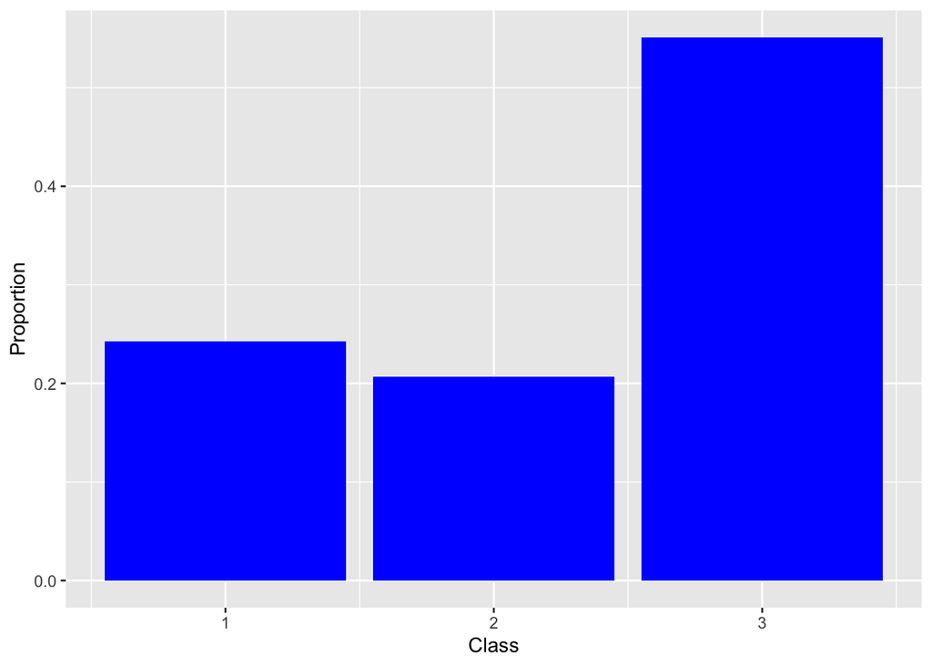

```r
titanic_new <- titanic %>% mutate(Class = Pclass)
plot_class <- ggplot(titanic_new,aes(x = Class, y = ..prop.., group = 1))+
  geom_bar(fill = "blue") + ylab("Proportion")
plot_class
```

From this graph, it is clear that there are significantly more passengers in third class than first or second class.

This next graph is showing a comparison between the three classes of passengers by showing the proportion of those passengers that survived or did not survive.

```r
counts_titanic <- titanic_new %>%
  group_by(Class, Survived) %>%
  summarise(Count = n())
prop_titanic <- counts_titanic %>% mutate(total_count = sum(Count)) %>%
  mutate(prop_class = Count/total_count)
prop_titanic
```

```
## # A tibble: 6 × 5
## # Groups:   Class [3]
##   Class Survived Count total_count prop_class
##   <int>    <int> <int>       <int>      <dbl>
## 1     1        0    80         216      0.370
## 2     1        1   136         216      0.630
## 3     2        0    97         184      0.527
## 4     2        1    87         184      0.473
## 5     3        0   372         491      0.758
## 6     3        1   119         491      0.242
```

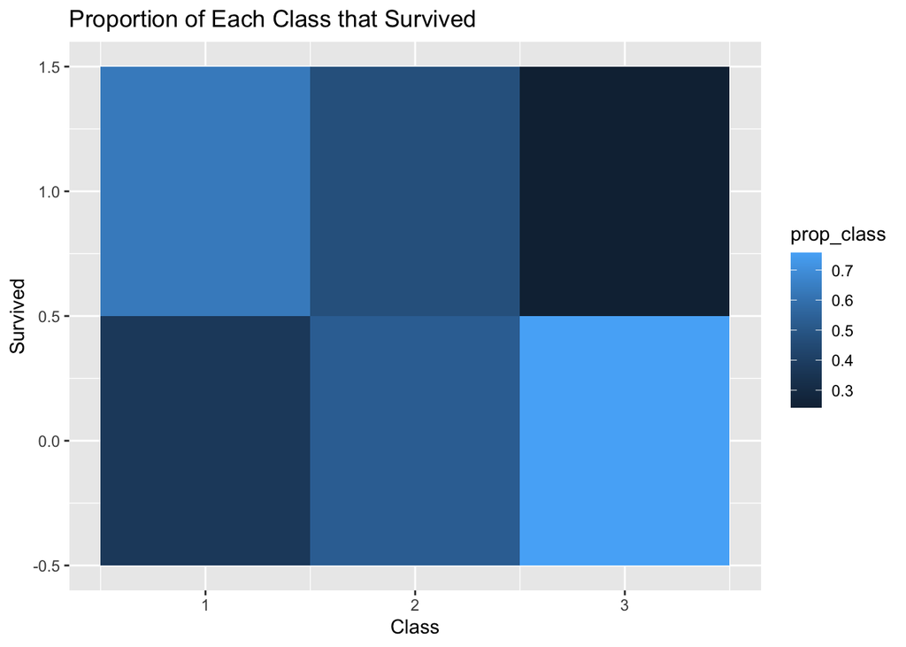

```r
count_graph <- ggplot(prop_titanic, aes(x = Class, y = Survived, fill = prop_class))+
 geom_tile() + labs(title = "Proportion of Each Class that Survived")
count_graph
```

The top block for each class represents the proportion of the class that survived, while the bottom block represents the proportion of that class that did not survive. This graph shows that there are more 1st class passengers that survived than did not survive. Also, the graph shows that there are slightly more 2nd class passengers that did not survive than survived. It also shows that there are significantly more 3rd class passengers that did not survive than did survive.

This next graph shows the association between wealth of the passenger, through ticket fare and class, and survival of the passengers.

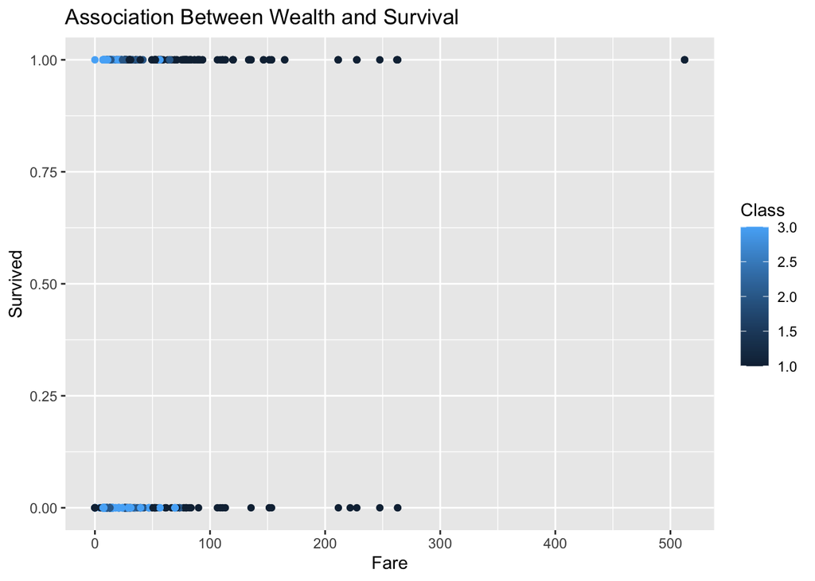

```r
class_graph <- ggplot(titanic_new, aes(y = Survived, x = Fare)) + geom_point(aes(color = Class)) + labs(title ="Association Between Wealth and Survival")
class_graph
```

The graph does not show a clear association between the wealth of the passenger and the passenger’s survival. I will continue by doing a decision tree with the same predictors to see if I can get results that can conclude if there is an association.

### Predicting Survivorship Through Wealth Associated Variables

Below, a decision tree is created with Fare and Class to predict survivorship of the passenger.

```r
form_tree1 <- as.formula(Survived~Fare + Class)
mod_tree_1 <- rpart(form_tree1, data = titanic_new)
mod_tree_1
```

```
## n= 891
##
## node), split, n, deviance, yval
##       * denotes terminal node
##
##  1) root 891 210.7273000 0.38383840
##    2) Class>=2.5 491  90.1588600 0.24236250
##      4) Fare< 10.825 328  53.3140200 0.20426830 *
##      5) Fare>=10.825 163  35.4110400 0.31901840
##       10) Fare>=13.7625 152  29.9407900 0.26973680
##         20) Fare>=23.35 66   7.7727270 0.13636360 *
##         21) Fare< 23.35 86  20.0930200 0.37209300
##           42) Fare< 15.1729 19   0.9473684 0.05263158 *
##           43) Fare>=15.1729 67  16.6567200 0.46268660 *
##       11) Fare< 13.7625 11   0.0000000 1.00000000 *
##    3) Class< 2.5 400  98.6775000 0.55750000
##      6) Fare< 13.64585 94  20.4255300 0.31914890 *
##      7) Fare>=13.64585 306  71.2712400 0.63071900
##       14) Fare< 52.2771 171  42.3274900 0.54970760 *
##       15) Fare>=52.2771 135  26.4000000 0.73333330 *
```

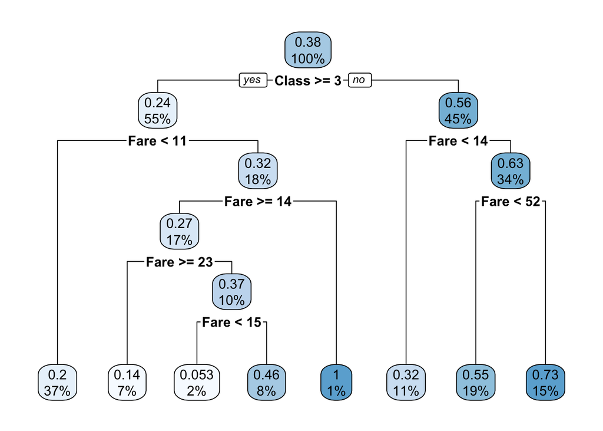

```r
rpart.plot(mod_tree_1)
```

Based on the outcome, this decision tree does imply that being in a lower class and having a lower fare is associated with lower likelihood of survival. However, I need to split the data into a training and testing set to do a better analysis.

Below, the data is split into a testing and training set.

```r
set.seed(100)
train <- titanic_new %>% sample_frac(size = 0.8)
test <- titanic_new %>% setdiff(train)
```

Next, three different decision trees are created, with different cp’s, to see which gives the best result. A confusion matrix is created, so it is clear if the model does well at predicting new data. The misclassification error rate is also calculated, to quantify how many times the tree incorrectly predicted survival.

```r
form_tree <- as.formula("Survived~Fare + Class")
mod_tree_2 <- rpart(form_tree, data = train, control = rpart.control(cp = 0.05))
mod_tree_3 <- rpart(form_tree, data = train, control = rpart.control(cp = 0.01))
mod_tree_4 <- rpart(form_tree, data = train, control = rpart.control(cp = 0.005))

confusion_matrix <- function(data, y, mod){
  confusion_matrix <- data %>%
    mutate(pred = predict(mod, newdata = data), y=y) %>%
    dplyr::select(y, pred) %>%
    table()
}
misclass <- function(confusion){
  misclass <- 1- sum(diag(confusion))/sum(confusion)
  misclass
}
```

```r
confusion_tree2_test <- confusion_matrix(test, test$Survived, mod_tree_2)
confusion_tree2_train <- confusion_matrix(train, train$Survived, mod_tree_2)

confusion_tree3_test <- confusion_matrix(test, test$Survived, mod_tree_3)
confusion_tree3_train <- confusion_matrix(train, train$Survived, mod_tree_3)

confusion_tree4_test <- confusion_matrix(test, test$Survived, mod_tree_4)
confusion_tree4_train <- confusion_matrix(train, train$Survived, mod_tree_4)

tibble(
  model = c("tree2", "tree3", "tree4"),
  cp = c(0.05, 0.01, 0.005),
  trainerror = c(misclass(confusion_tree2_train), misclass(confusion_tree3_train), misclass(confusion_tree4_train)),
  testerror = c(misclass(confusion_tree2_test), misclass(confusion_tree3_test), misclass(confusion_tree4_test))
)
```

```
## # A tibble: 3 × 4
##   model    cp trainerror testerror
##   <chr> <dbl>      <dbl>     <dbl>
## 1 tree2 0.05       0.330     0.343
## 2 tree3 0.01       0.987     0.978
## 3 tree4 0.005      0.987     0.978
```

The misclassification rate is high for both the training and testing data sets, for trees 3 and 4 trees. However, tree 2, with a cp of 0.05 gives good levels of error rate. So, the best cp for this data is when the cp = 0.05.

# Prediction Model

### Finding the Significant Predictors

```r
full.mod=lm(Survived~Pclass+Sex+Age+Parch+Fare, data=titanic.f)
final <- stepAIC(full.mod,direction = 'both', trace=0)
summary(final)
```

```
##
## Call:
## lm(formula = Survived ~ Pclass + Sex + Age + Parch, data = titanic.f)
##
## Residuals:
##      Min       1Q   Median       3Q      Max
## -1.08321 -0.25125 -0.07078  0.21818  1.00370
##
## Coefficients:
##              Estimate Std. Error t value Pr(>|t|)
## (Intercept)  1.353659   0.064911  20.854  < 2e-16 ***
## Pclass      -0.202924   0.018871 -10.753  < 2e-16 ***
## Sexmale     -0.490774   0.031481 -15.590  < 2e-16 ***
## Age         -0.005729   0.001094  -5.235 2.17e-07 ***
## Parch       -0.028035   0.017665  -1.587    0.113
## ---
## Signif. codes:  0 '***' 0.001 '**' 0.01 '*' 0.05 '.' 0.1 ' ' 1
##
## Residual standard error: 0.3842 on 709 degrees of freedom
##   (177 observations deleted due to missingness)
## Multiple R-squared:  0.3923, Adjusted R-squared:  0.3889
## F-statistic: 114.4 on 4 and 709 DF,  p-value: < 2.2e-16
```

### Splitting the data into a training and testing data set

```r
set.seed(100)
train <- tidyTitanic %>% sample_frac(size = 0.8)
test <- tidyTitanic %>% setdiff(train)
```

### Fitting titanic data to a logistic regression model

```r
library(glmnet)
form_lr1 <- as.formula("Survived ~ Age + Sex + Pclass")
predictors <- model.matrix(form_lr1, data = train)
fit1 <- glmnet(predictors, train$Survived, family = "binomial", lambda = 0)
fit1$beta
```

```
## 4 x 1 sparse Matrix of class "dgCMatrix"
##                      s0
## (Intercept)  .
## Age         -0.03405078
## Sexmale     -2.63114136
## Pclass      -1.26686386
```

From this model, we can observe that as Age increases, the passenger’s chance for Survival decreases. If a passenger is male, there chance for survival decreases. If the passenger was travelling in a higher class, like class 3, their chance of survival decreased. Overall, Age and class have the lowest relationship to a passenger’s chance for survival, and a passenger’s sex has the highest relationship to a passenger’s chance for survival.

### Calculating the misclassification rate of the logistic regression

```r
logistic.misclassrate <- function(dataset,y, fit,form ){
  misclass_lr <- dataset %>%
  mutate(pred.logistic = predict(fit, newx = model.matrix(form, data  = dataset),
         type = "class")) %>%
  mutate(misclassify = ifelse(y != pred.logistic, 1,0))  %>%
  summarize(misclass.rate=mean(misclassify))
  return(misclass_lr$misclass.rate)
}
misclassrate<-logistic.misclassrate(test,test$Survived,fit1,form_lr1)
misclassrate
```

```
## [1] 0.2307692
```

This logistic model gives the testing misclassification rate of 0.23

### Finding the optimal lambda to use for logistic regression model

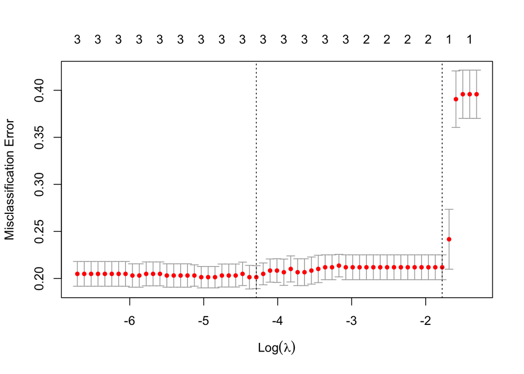

```r
cv.fit <- cv.glmnet(predictors, train$Survived, nfolds=10,
                    family = "binomial", type.measure = "class")
plot(cv.fit)
```

### Fitting titanic data to optimal Logistic Regression models

This Logistic Regression Model uses the largest lambda within 1 standard error of the minimum

```r
coef(cv.fit,s="lambda.1se")
```

```
## 5 x 1 sparse Matrix of class "dgCMatrix"
##                     s1
## (Intercept)  0.1270036
## (Intercept)  .
## Age          .
## Sexmale     -0.8717649
## Pclass       .
```

```r
coef(cv.fit,s="lambda.min")
```

```
## 5 x 1 sparse Matrix of class "dgCMatrix"
##                      s1
## (Intercept)  3.97188866
## (Intercept)  .
## Age         -0.02273888
## Sexmale     -2.38335357
## Pclass      -1.03092278
```

# Appendix

### Part I

- **Shreya Agrawal:** drug_use
- **Elizabeth Imhoff:** bad_drivers
- **Emily Jolly:** congress_age

### Contributions

- **Shreya Agrawal:** Shreya completed all of the age analyses and the logistic regression model
- **Elizabeth Imhoff:** Elizabeth completed all of the wealth class analyses
- **Emily Jolly:** Emily completed all of the sex analyses and the AIC step